# Processing time series in a generic way

*VARATHALINGAM Mayouran*

The objective of this project is to create functions capable of processing time series in a generic way

*1 : Import necessary libraries*

```python
import pandas as pd
import numpy as np
import matplotlib.pyplot as plt
```

*2 : use pandas to read csv*

```python
df2 = pd.read_csv('.spyder-py3\ProjectPbi\log.csv',sep=';',parse_dates=True,decimal=',')
df1 = pd.read_csv('.spyder-py3\ProjectPbi\dico.csv',sep=';')
```

Used separators and parse_dates to deal with the log.csv without modifying the csv itself

*3 : Deal with the problems of log.csv and creation of a new dataframe*

```python
df2.columns = ['Id','Timestamp','Value']
df = pd.merge(df1[['Id','equipement_ouptut']],df2, on='Id')
```

*4:Separate data by Id in multiple Dataframe*

First I'll create a function that return a list to save all the Id's to keep the generic side ( if df1 changed we can still have all the new Id ) then a function is needed to separate all the data by Id's from the big Dataframe just created

```python
def idlist(df1):
    listid=[]
    for i in df1.index:

        listid.append(df1['Id'][i])

    return (listid)
```

```python
x=idlist(df1)
print(x)
```

```
[726, 727, 261, 140, 262, 142, 141, 629, 125, 126, 127, 129, 121, 119, 123, 720, 721, 723, 724, 258, 259, 377, 378, 256, 257, 135, 138, 139, 254, 255, 136, 137, 246, 247, 250, 251, 244, 245, 252]
```

```python
def idseparate(df,listid):
    mydicti = {}
    for i in listid:

        dff=df.loc[df['Id']==i]

        dfff=dff[['equipement_ouptut','Timestamp','Value']].copy()

        mydicti[i]=dfff
    return (mydicti)
```

```python
y=idseparate(df,x)
print(y)
```

```
{726:       equipement_ouptut                Timestamp    Value
0                 Index  2017-03-15 10:27:52.000  23650.0
1                 Index  2017-03-15 10:32:50.000  23651.0
2                 Index  2017-03-15 10:37:51.000  23651.0
3                 Index  2017-03-15 10:42:50.000  23652.0
4                 Index  2017-03-15 10:47:50.000  23652.0
5                 Index  2017-03-15 10:52:50.000  23653.0
6                 Index  2017-03-15 10:57:50.000  23653.0
7                 Index  2017-03-15 11:02:50.000  23654.0
8                 Index  2017-03-15 11:07:50.000  23654.0
9                 Index  2017-03-15 11:21:45.000  23655.0
10                Index  2017-03-15 11:26:46.000  23656.0
11                Index  2017-03-15 11:31:45.000  23656.0
12                Index  2017-03-15 11:36:45.000  23657.0
13                Index  2017-03-15 11:41:45.000  23657.0
```

[output cut: 2443 more lines]

return a dictionnary with Id -> device id and Values -> equipement_output, Timestamp and Value

*5: Exploratory Data Analysis*

```python
print(df2.head(5))
print(df1.head(5))

print(df2.shape)
print(df1.shape)

print(df2.columns)
print(df1.columns)
```

```
    Id                Timestamp  Value
0  119  2016-10-21 09:47:05.000    0.0
1  119  2016-10-21 09:47:24.000    0.0
2  119  2016-10-21 09:47:49.000    0.0
3  119  2016-10-21 09:48:08.000    0.0
4  119  2016-10-21 09:48:26.000    0.0
    Id            eui_id  tc_input equipement_ouptut
0  726  70b3d59ba0000465         1             Index
1  727  70b3d59ba0000465         3             Index
2  261  70b3d59ba0000605         0    Delta Pression
3  140  70b3d59ba00005c9         0    Delta Pression
4  262  70b3d59ba00005c3         0    Delta Pression
(1153585, 3)
(39, 4)
Index(['Id', 'Timestamp', 'Value'], dtype='object')
Index(['Id', 'eui_id', 'tc_input', 'equipement_ouptut'], dtype='object')
```

First , let's have a look to both Dataframes data The number of data is really huge that's why it needs some rearrangement

Manipulate Data on those dataframe seems complicated because of the dtype='object', some modification can definitely help !

*5-1 : Index Values*

When the equipement_output is 'Index' , the value at t+1 is equal or greater than the value at t Let's make a function to check this in a generic way

First let's create a list to have all the Id which have 'Index' as equipement output

```python
def indexlist(df1):
    listid=[]
    for i in df1.index:
        if df1['equipement_ouptut'][i]=='Index':
            listid.append(df1['Id'][i])

    return (listid)

indexl=indexlist(df1)
print(indexl)
```

```
[726, 727, 629, 125, 126, 127, 129, 121, 119, 123, 720, 721, 723, 724]
```

```python
def getindexvalue(df,indexlist):
    b={}
    for i in indexlist:
        dff=df.loc[df['Id']==i]
        a=dff.get('Value')
        c=pd.to_numeric(a,downcast='float')
        for val in c:
            if val>val+1:
                b[i]=-1
            else:
                b[i]=1



    return(b)

indexv=getindexvalue(df,indexl)
print(indexv)
```

```
{726: 1, 727: 1, 629: 1, 125: 1, 126: 1, 127: 1, 129: 1, 121: 1, 119: 1, 123: 1, 720: 1, 721: 1, 723: 1, 724: 1}
```

*5-2 Pressure,Temperature Values*

Concerning those output, it's not really the same. In fact, here it'll be more interresting to see the mean of values

First let's see the if there is any null values

```python
print(df['Id'][df['Value'].isnull()].tolist())
print(df['equipement_ouptut'][df['Value'].isnull()].tolist())
```

```
[258, 258, 135, 135, 136, 136, 136]
['Humidité', 'Humidité', 'Humidité', 'Humidité', 'Humidité', 'Humidité', 'Humidité']
```

*5-2-1 Temperature*

```python
def Temperaturelist(df1):
    listid=[]
    for i in df1.index:
        if df1['equipement_ouptut'][i]=='Température':
            listid.append(df1['Id'][i])

    return (listid)

Temperaturel=Temperaturelist(df1)
print(Temperaturel)
```

```
[259, 378, 257, 139, 255, 137, 246, 247, 250, 251, 244, 245, 252]
```

```python
def getTemperaturevalue(df,Temperaturelist):
    b={}

    for i in Temperaturelist:
        dff=df.loc[df['Id']==i]
        a=dff.get('Value')

        c=pd.to_numeric(a,downcast='float')
        b[i]=c.mean()





    return(b)

temperaturev=getTemperaturevalue(df,Temperaturel)
print(temperaturev)
```

[output not shown]

now let's see the scatter plot of these dictinnary to see the disparsal of mean values

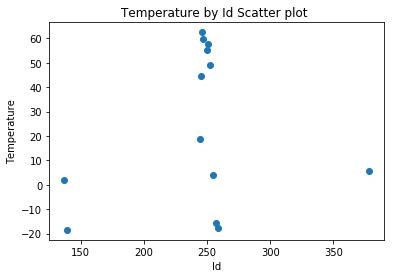

```python
def getTemperaturevalue(df,Temperaturelist):
    b={}

    for i in Temperaturelist:
        dff=df.loc[df['Id']==i]
        a=dff.get('Value')

        c=pd.to_numeric(a,downcast='float')
        b[i]=c.mean()


    plt.scatter(b.keys(),b.values())
    plt.title('Temperature by Id Scatter plot ')
    plt.xlabel('Id')
    plt.ylabel('Temperature')
    plt.show()




Temperaturep=getTemperaturevalue(df,Temperaturel)
```

Looking at this plot , we can find that most of the temperature output equipemement have an Id close to 250. But we can also guess the minimum and maximum of mean values.

Max Mean Temperature Value

```python
def maxtemperature(temperaturev):
    maxi=0
    for i in temperaturev:
        if maxi<temperaturev[i]:
            maxi=temperaturev[i]
    return maxi

maxmean=maxtemperature(temperaturev)
print(maxmean)
```

```
62.54481887817383
```

Index of Max Mean Temperature Value

```python
def maxindextemperature(temperaturev):
    maxi=0
    index=0

    for i in temperaturev:

        if maxi<temperaturev[i]:
            maxi=temperaturev[i]
            index=i

    return index

maxmeanindex=maxindextemperature(temperaturev)
print(maxmeanindex)
```

```
246
```

Min Mean Temperature Value

```python
def mintemperature(temperaturev):
    mini=0
    for i in temperaturev:
        if mini>temperaturev[i]:
            mini=temperaturev[i]
    return mini

minmean=mintemperature(temperaturev)
print(minmean)
```

```
-18.50017738342285
```

Index of Min Mean Temperature Value

```python
def minindextemperature(temperaturev):
    mini=0
    index=0

    for i in temperaturev:

        if mini>temperaturev[i]:
            mini=temperaturev[i]
            index=i

    return index

minmeanindex=minindextemperature(temperaturev)
print(minmeanindex)
```

```
139
```

*5-2-2 Pression*

```python
def Pressionlist(df1):
    listid=[]
    for i in df1.index:
        if df1['equipement_ouptut'][i]=='Delta Pression':
            listid.append(df1['Id'][i])

    return (listid)

Pressionl=Pressionlist(df1)
print(Pressionl)
```

```
[261, 140, 262, 142, 141]
```

```python
def getTPressionvalue(df,Pressionlist):
    b={}

    for i in Pressionlist:
        dff=df.loc[df['Id']==i]
        a=dff.get('Value')

        c=pd.to_numeric(a,downcast='float')
        b[i]=c.mean()





    return(b)

Pressionv=getTPressionvalue(df,Pressionl)
print(Pressionv)
```

```
{261: 4.244833946228027, 140: 4.211487770080566, 262: 4.768059730529785, 142: 4.410276412963867, 141: 4.442330360412598}
```

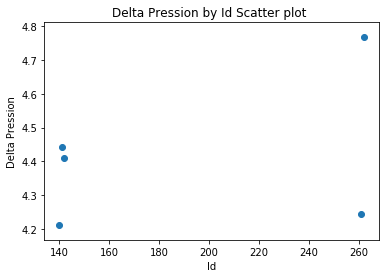

```
None
```

```python
def getTPressionvalue(df,Pressionlist):
    b={}

    for i in Pressionlist:
        dff=df.loc[df['Id']==i]
        a=dff.get('Value')

        c=pd.to_numeric(a,downcast='float')
        b[i]=c.mean()

    plt.scatter(b.keys(),b.values())
    plt.title('Delta Pression by Id Scatter plot ')
    plt.xlabel('Id')
    plt.ylabel('Delta Pression')
    plt.show()







Pressionva=getTPressionvalue(df,Pressionl)
print(Pressionva)
```

The value for the delta pression are quite similar in fact there is no big dispersion

Max Mean Delta Pression Value

```python
def maxPression(Pressionv):
    maxip=0
    for i in Pressionv:
        if maxip<Pressionv[i]:
            maxip=Pressionv[i]
    return maxip

maxmeanp=maxPression(Pressionv)
print(maxmeanp)
```

```
4.768059730529785
```

Max Mean Delta Pression Id Value

```python
def maxindexPression(Pressionv):
    maxi=0
    index=0

    for i in Pressionv:

        if maxi<Pressionv[i]:
            maxi=Pressionv[i]
            index=i

    return index

maxmeanindexp=maxindexPression(Pressionv)
print(maxmeanindexp)
```

```
262
```

*5-2-3 Humidity*

```python
def Humiditylist(df1):
    listid=[]
    for i in df1.index:
        if df1['equipement_ouptut'][i]=='Humidité':
            listid.append(df1['Id'][i])

    return (listid)

Humidityl=Humiditylist(df1)
print(Humidityl)
```

```
[258, 377, 256, 135, 138, 254, 136]
```

```python
def getHumidityvalue(df,Humiditylist):
    b={}

    for i in Humiditylist:
        dff=df.loc[df['Id']==i]
        a=dff.get('Value')

        c=pd.to_numeric(a,downcast='float')
        b[i]=c.mean()





    return(b)

Humidityv=getHumidityvalue(df,Humidityl)
print(Humidityv)
```

```
{258: 58.60663604736328, 377: 74.69071960449219, 256: 55.31620407104492, 135: 90.00601959228516, 138: 59.66246795654297, 254: 88.56869506835938, 136: 83.4982681274414}
```

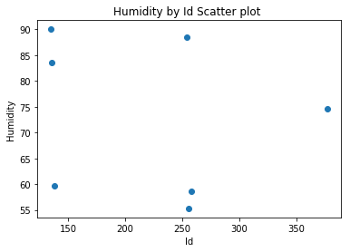

```
None
```

```python
def getHumidityvalue(df,Humiditylist):
    b={}

    for i in Humiditylist:
        dff=df.loc[df['Id']==i]
        a=dff.get('Value')

        c=pd.to_numeric(a,downcast='float')
        b[i]=c.mean()


    plt.scatter(b.keys(),b.values())
    plt.title('Humidity by Id Scatter plot ')
    plt.xlabel('Id')
    plt.ylabel('Humidity')
    plt.show()




Humidityva=getHumidityvalue(df,Humidityl)
print(Humidityva)
```

The dispersion is really visible there is no clear indictaion about how it is scatter

Max Mean Value

```python
def maxHumidity(Humidityv):
    maxih=0
    for i in Humidityv:
        if maxih<Humidityv[i]:
            maxih=Humidityv[i]
    return maxih

maxmeanh=maxHumidity(Humidityv)
print(maxmeanh)
```

```
90.00601959228516
```

Max Index Value Mean Humidity

```python
def maxindexHumidity(Humidityv):
    maxih=0
    index=0
    for i in Humidityv:
        if maxih<Humidityv[i]:
            maxih=Humidityv[i]
            index=i
    return index

maxmeanindexh=maxindexHumidity(Humidityv)
print(maxmeanindexh)
```

```
135
```

*6 Data Sampling*

*6-1 Temperature Mean Sampling (Hour,Day,Week,Month)*

```
[259, 378, 257, 139, 255, 137, 246, 247, 250, 251, 244, 245, 252]
               Id      Value
Timestamp
2016-11-29  252.0  48.881818
2016-11-30  252.0  46.618644
2016-12-01  252.0  47.370504
2016-12-02  252.0  47.143885
2016-12-03  252.0  47.258993
2016-12-04  252.0  46.759124
2016-12-05  252.0  46.889706
2016-12-06  252.0  46.393130
2016-12-07  252.0  48.720588
2016-12-08  252.0  48.422794
2016-12-09  252.0  47.966667
2016-12-10  252.0  49.463504
2016-12-11  252.0  48.287770
2016-12-12  252.0  46.237037
2016-12-13  252.0  47.829710
2016-12-14  252.0  47.669065
2016-12-15  252.0  49.146429
2016-12-16  252.0  47.236641
2016-12-17  252.0  48.776000
2016-12-18  252.0  47.860169
2016-12-19  252.0  48.344000
2016-12-20  252.0  48.287611
2016-12-21  252.0  48.017094
2016-12-22  252.0  47.722826
2016-12-23  252.0  43.883333
2016-12-24  252.0  45.774194
2016-12-25  252.0  42.775862
2016-12-26  252.0  45.150000
2016-12-27  252.0  47.133333
2016-12-28  252.0  47.416667
...           ...        ...
2017-07-20  252.0  51.171875
2017-07-21  252.0  50.656250
2017-07-22  252.0  52.000000
2017-07-23  252.0  50.520000
2017-07-24  252.0  49.141791
2017-07-25  252.0  49.880952
```

[output cut: 11 more lines]

```
2017-08-06  252.0  49.235915
2017-08-07  252.0  50.452899
2017-08-08  252.0  50.100000
2017-08-09  252.0  49.966418
2017-08-10  252.0  49.137681
2017-08-11  252.0  49.177536
2017-08-12  252.0  48.308511
2017-08-13  252.0  49.982394
2017-08-14  252.0  49.797203
2017-08-15  252.0  49.146429
2017-08-16  252.0  50.600000
2017-08-17  252.0  50.791971
2017-08-18  252.0  49.679245

[263 rows x 2 columns]
```

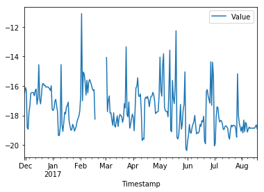

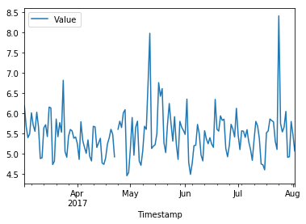

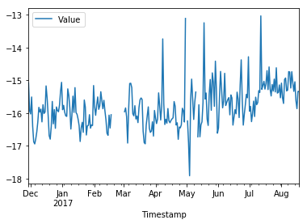

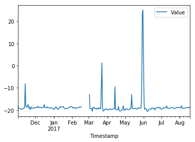

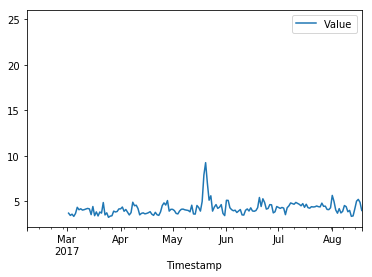

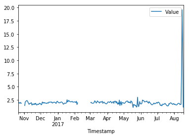

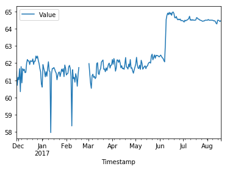

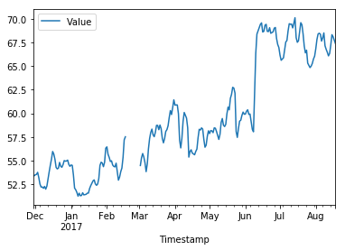

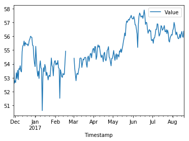

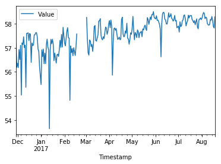

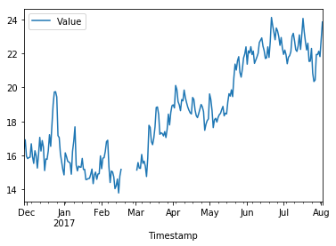

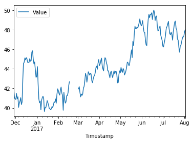

[1 more figures not shown]

```python
def Temperaturelist(df1):
    listid=[]
    for i in df1.index:
        if df1['equipement_ouptut'][i]=='Température':
            listid.append(df1['Id'][i])

    return (listid)

Temperaturel=Temperaturelist(df1)
print(Temperaturel)

def tempmean(Temperaturelist,df,x):


    for i in Temperaturelist:
        dff=df.loc[df['Id']==i]

        dfff = dff.set_index(pd.DatetimeIndex(dff['Timestamp']))
        dfff['Timestamp']=pd.to_datetime(dfff['Timestamp'])


        dfff['Value']=pd.to_numeric(dfff['Value'])

        df3 = dfff.set_index('Timestamp').resample(x).mean() #change D to have other parameter
        df3.plot( y='Value')
    return (df3)

f=tempmean(Temperaturel,df,'D') # Change D->Day by H-> Hour , W->week, M->Month
print(f)
```

So here we have each Temperature output's Id, one example for id=252 to see how the sample is made and plot ordered by the first list

*6-2 Data Pression Mean Sampling (Hour,Day,Week,Month)*

```
[261, 140, 262, 142, 141]
               Id     Value
Timestamp
2016-10-21  141.0  4.165368
2016-10-22  141.0  4.165248
2016-10-23  141.0  4.166840
2016-10-24  141.0  4.167510
2016-10-25  141.0  4.167414
2016-10-26  141.0  4.165838
2016-10-27  141.0  4.164901
2016-10-28    NaN       NaN
2016-10-29    NaN       NaN
2016-10-30    NaN       NaN
2016-10-31    NaN       NaN
2016-11-01    NaN       NaN
2016-11-02  141.0  4.167503
2016-11-03  141.0  4.166459
2016-11-04  141.0  4.166408
2016-11-05  141.0  4.168160
2016-11-06  141.0  4.167190
2016-11-07  141.0  4.168440
2016-11-08  141.0  4.168709
2016-11-09  141.0  4.168516
2016-11-10  141.0  4.168900
2016-11-11  141.0  4.168436
2016-11-12  141.0  4.169041
2016-11-13  141.0  4.169400
2016-11-14  141.0  4.168581
2016-11-15  141.0  4.167627
2016-11-16  141.0  4.168118
2016-11-17  141.0  4.167498
2016-11-18  141.0  4.167507
2016-11-19  141.0  4.167601
...           ...       ...
2017-07-20  141.0  4.790936
2017-07-21  141.0  4.812154
2017-07-22  141.0  4.820238
2017-07-23  141.0  4.814767
2017-07-24  141.0  4.815321
2017-07-25  141.0  4.819660
```

[output cut: 11 more lines]

```
2017-08-06  141.0  4.167314
2017-08-07  141.0  4.168097
2017-08-08  141.0  4.166808
2017-08-09  141.0  4.457865
2017-08-10  141.0  4.723692
2017-08-11  141.0  4.715831
2017-08-12  141.0  4.710176
2017-08-13  141.0  4.705961
2017-08-14  141.0  4.700668
2017-08-15  141.0  4.701649
2017-08-16  141.0  4.695957
2017-08-17  141.0  4.691600
2017-08-18  141.0  4.690982

[302 rows x 2 columns]
```

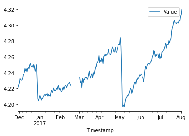

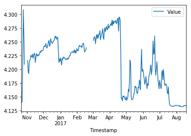

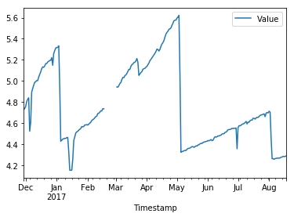

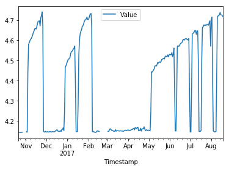

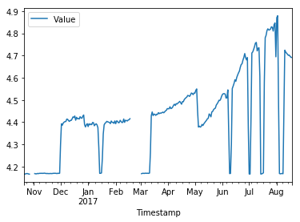

```python
def Pressionlist(df1):
    listid=[]
    for i in df1.index:
        if df1['equipement_ouptut'][i]=='Delta Pression':
            listid.append(df1['Id'][i])

    return (listid)

Pressionl=Pressionlist(df1)
print(Pressionl)

def pressionmean(Pressionlist,df,x):


    for i in Pressionlist:
        dff=df.loc[df['Id']==i]

        dfff = dff.set_index(pd.DatetimeIndex(dff['Timestamp']))
        dfff['Timestamp']=pd.to_datetime(dfff['Timestamp'])
        dfff['Value']=pd.to_numeric(dfff['Value'])

        df3 = dfff.set_index('Timestamp').resample(x).mean() #change D to have other parameter
        df3.plot( y='Value')
    return (df3)

n=pressionmean(Pressionl,df,'D') # Change D->Day by H-> Hour , W->week, M->Month
print(n)
```

*6-3 Humidité Mean Sampling (Hour,Day,Week,Month)*

```
[258, 377, 256, 135, 138, 254, 136]
             Id      Value
Timestamp
2016-10-31  136  79.287650
2016-11-30  136  80.286244
2016-12-31  136  81.896900
2017-01-31  136  82.248550
2017-02-28  136  81.363743
2017-03-31  136  83.918137
2017-04-30  136  84.803738
2017-05-31  136  84.694218
2017-06-30  136  85.278515
2017-07-31  136  86.048341
2017-08-31  136  85.139414
```

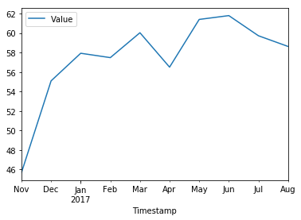

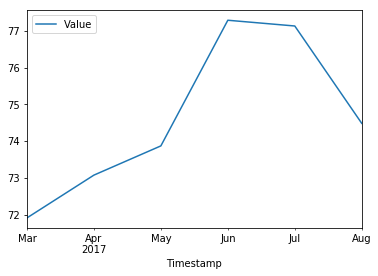

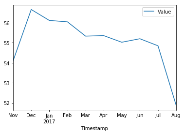

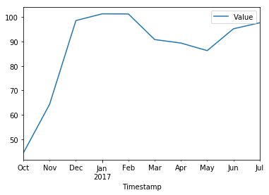

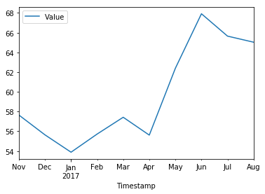

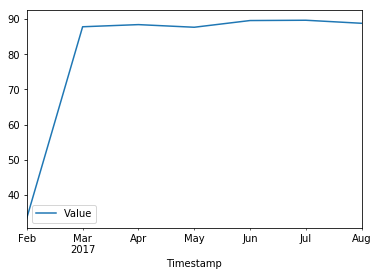

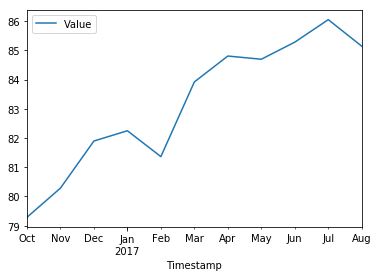

```python
def Humiditylist(df1):
    listid=[]
    for i in df1.index:
        if df1['equipement_ouptut'][i]=='Humidité':
            listid.append(df1['Id'][i])

    return (listid)

Humidityl=Humiditylist(df1)
print(Humidityl)

def humiditymean(Humiditylist,df,x):


    for i in Humiditylist:
        dff=df.loc[df['Id']==i]

        dfff = dff.set_index(pd.DatetimeIndex(dff['Timestamp']))
        dfff['Timestamp']=pd.to_datetime(dfff['Timestamp'])
        dfff['Value']=pd.to_numeric(dfff['Value'])

        df3 = dfff.set_index('Timestamp').resample(x).mean() #change D to have other parameter
        df3.plot( y='Value')
    return (df3)

b=humiditymean(Humidityl,df,'M') # Change D->Day by H-> Hour , W->week, M->Month
print(b)
```

Same thing we can see a list of all 'Humdité' output Id's, then a sample of how the data now looks like and finally plots of Id's in the list in the same order

*6-4 Linearization Index Values*

```python
def LIndexlist(df1):
    listid=[]
    for i in df1.index:
        if df1['equipement_ouptut'][i]=='Index':
            listid.append(df1['Id'][i])

    return (listid)

Indexl=LIndexlist(df1)
print(Indexl)

def linearindex(Indexl,df,x):


    for i in Indexl:
        dff=df.loc[df['Id']==i]

        dfff = dff.set_index(pd.DatetimeIndex(dff['Timestamp']))
        dfff['Timestamp']=pd.to_datetime(dfff['Timestamp'])
        dfff['Value']=pd.to_numeric(dfff['Value'])


        #Linearization
        oidx=dfff.index
        nidx=pd.date_range(oidx.min(), oidx.max(), freq=x)
        df4=dfff.reindex(oidx.union(nidx)).interpolate('index').reindex(nidx)
        print(i)
        df4=df4.get('Value')

        print(df4.head(10))


        #2nd method to linearize
        """
        df3 = dfff.set_index('Timestamp')
        df3=df3.resample('x').ffill(limit=1)
        df4=df3.interpolate(method='linear')

        """
    #return (df4)

fq=linearindex(Indexl,df,'D')# Change D->Day by H-> Hour , W->week, M->Month
print(fq)
```

```
[726, 727, 629, 125, 126, 127, 129, 121, 119, 123, 720, 721, 723, 724]
726
2017-03-15 10:27:52    23650.000000
2017-03-16 10:27:52    23804.541806
2017-03-17 10:27:52    23965.000000
2017-03-18 10:27:52    24100.000000
2017-03-19 10:27:52    24241.000000
2017-03-20 10:27:52    24375.637874
2017-03-21 10:27:52    24540.666667
2017-03-22 10:27:52    24705.000000
2017-03-23 10:27:52    24867.571906
2017-03-24 10:27:52    25032.000000
Freq: D, Name: Value, dtype: float64
727
2017-03-15 09:07:55    25501.000000
2017-03-16 09:07:55    25688.535354
2017-03-17 09:07:55    25860.538462
2017-03-18 09:07:55    26012.573333
2017-03-19 09:07:55    26143.000000
2017-03-20 09:07:55    26271.000000
2017-03-21 09:07:55    26433.659933
2017-03-22 09:07:55    26614.691275
2017-03-23 09:07:55    26790.563333
2017-03-24 09:07:55    26973.568106
Freq: D, Name: Value, dtype: float64
629
2017-03-10 05:26:01    102.0
2017-03-11 05:26:01    103.0
2017-03-12 05:26:01    104.0
2017-03-13 05:26:01    105.0
2017-03-14 05:26:01    105.0
2017-03-15 05:26:01    108.0
2017-03-16 05:26:01    111.0
2017-03-17 05:26:01    114.0
2017-03-18 05:26:01    115.0
2017-03-19 05:26:01    115.0
Freq: D, Name: Value, dtype: float64
125
2016-10-21 10:12:29    1060.000000
2016-10-22 10:12:29    1231.944972
```

[output cut: 115 more lines]

```
2017-03-24 04:32:44    21098.568562
Freq: D, Name: Value, dtype: float64
724
2017-03-15 06:57:50    31082.000000
2017-03-16 06:57:50    31301.545151
2017-03-17 06:57:50    31512.548173
2017-03-18 06:57:50    31717.576667
2017-03-19 06:57:50    31894.612040
2017-03-20 06:57:50    32080.642140
2017-03-21 06:57:50    32292.672241
2017-03-22 06:57:50    32500.701342
2017-03-23 06:57:50    32710.573333
2017-03-24 06:57:50    32925.576667
Freq: D, Name: Value, dtype: float64
None
```

A list of all Index Id's and new dataframes with Id's after linearization

We have A list of all Index output, so if a csv is needed for a certain Id

```python
def LIndexlist(df1):
    listid=[]
    for i in df1.index:
        if df1['equipement_ouptut'][i]=='Index':
            listid.append(df1['Id'][i])

    return (listid)

Indexl=LIndexlist(df1)
print(Indexl)

def linearindexcsv(df,x,n):
        dff=df.loc[df['Id']==n]

        dfff = dff.set_index(pd.DatetimeIndex(dff['Timestamp']))
        dfff['Timestamp']=pd.to_datetime(dfff['Timestamp'])
        dfff['Value']=pd.to_numeric(dfff['Value'])


        #Linearization
        oidx=dfff.index
        nidx=pd.date_range(oidx.min(), oidx.max(), freq=x)
        df4=dfff.reindex(oidx.union(nidx)).interpolate('index').reindex(nidx)

        df4=df4.get('Value')

        print(df4.head(10))

        #filenaming (the same thing can be made for other output type)
        file_name=str(n)+'by'+x+'.csv'
        df4.to_csv('file_name',encoding='utf-8')


        #2nd method to linearize
        """
        df3 = dfff.set_index('Timestamp')
        df3=df3.resample('x').ffill(limit=1)
        df4=df3.interpolate(method='linear')

        """
    #return (df4)





fq=linearindexcsv(df,'D',724)# Change D->Day by H-> Hour , W->week, M->Month
print(fq)
```

```
[726, 727, 629, 125, 126, 127, 129, 121, 119, 123, 720, 721, 723, 724]
2017-03-15 06:57:50    31082.000000
2017-03-16 06:57:50    31301.545151
2017-03-17 06:57:50    31512.548173
2017-03-18 06:57:50    31717.576667
2017-03-19 06:57:50    31894.612040
2017-03-20 06:57:50    32080.642140
2017-03-21 06:57:50    32292.672241
2017-03-22 06:57:50    32500.701342
2017-03-23 06:57:50    32710.573333
2017-03-24 06:57:50    32925.576667
Freq: D, Name: Value, dtype: float64
None
```

And finally if plot is needed

```
[726, 727, 629, 125, 126, 127, 129, 121, 119, 123, 720, 721, 723, 724]
None
```

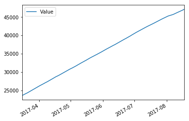

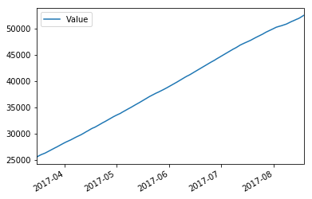

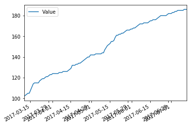

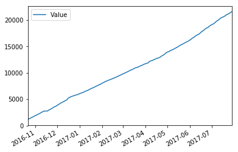

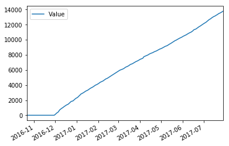

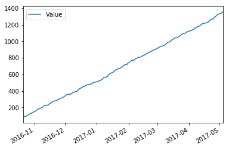

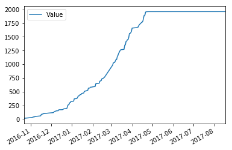

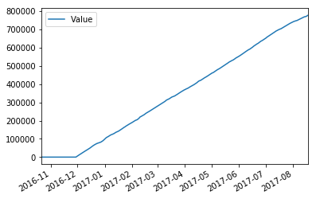

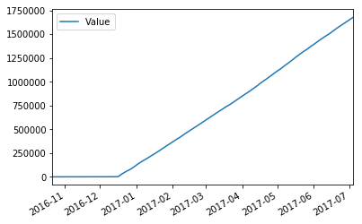

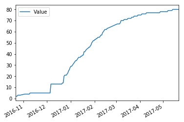

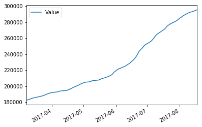

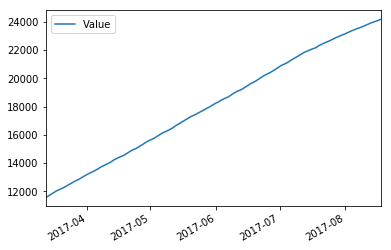

[2 more figures not shown]

```python
def LIndexlist(df1):
    listid=[]
    for i in df1.index:
        if df1['equipement_ouptut'][i]=='Index':
            listid.append(df1['Id'][i])

    return (listid)

Indexl=LIndexlist(df1)
print(Indexl)

def linearindexplot(Indexl,df,x):


    for i in Indexl:
        dff=df.loc[df['Id']==i]

        dfff = dff.set_index(pd.DatetimeIndex(dff['Timestamp']))
        dfff['Timestamp']=pd.to_datetime(dfff['Timestamp'])
        dfff['Value']=pd.to_numeric(dfff['Value'])


        #Linearization
        oidx=dfff.index
        nidx=pd.date_range(oidx.min(), oidx.max(), freq=x)
        df4=dfff.reindex(oidx.union(nidx)).interpolate('index').reindex(nidx)


        df4.plot( y='Value')




        #2nd method to linearize
        """
        df3 = dfff.set_index('Timestamp')
        df3=df3.resample('x').ffill(limit=1)
        df4=df3.interpolate(method='linear')

        """
    #return (df4)

fq=linearindexplot(Indexl,df,'D')# Change D->Day by H-> Hour , W->week, M->Month
print(fq)
```